# Data Scientist Nanodegree

## Convolutional Neural Networks

## Project: Write an Algorithm for a Dog Identification App

This notebook walks you through one of the most popular Udacity projects across machine learning and artificial intellegence nanodegree programs. The goal is to classify images of dogs according to their breed.

If you are looking for a more guided capstone project related to deep learning and convolutional neural networks, this might be just it. Notice that even if you follow the notebook to creating your classifier, you must still create a blog post or deploy an application to fulfill the requirements of the capstone project.

Also notice, you may be able to use only parts of this notebook (for example certain coding portions or the data) without completing all parts and still meet all requirements of the capstone project.

In this notebook, some template code has already been provided for you, and you will need to implement additional functionality to successfully complete this project. You will not need to modify the included code beyond what is requested. Sections that begin with **'(IMPLEMENTATION)'** in the header indicate that the following block of code will require additional functionality which you must provide. Instructions will be provided for each section, and the specifics of the implementation are marked in the code block with a 'TODO' statement. Please be sure to read the instructions carefully!

In addition to implementing code, there will be questions that you must answer which relate to the project and your implementation. Each section where you will answer a question is preceded by a **'Question X'** header. Carefully read each question and provide thorough answers in the following text boxes that begin with **'Answer:'**. Your project submission will be evaluated based on your answers to each of the questions and the implementation you provide.

> **Note:** Code and Markdown cells can be executed using the **Shift + Enter** keyboard shortcut. Markdown cells can be edited by double-clicking the cell to enter edit mode.

The rubric contains *optional* "Stand Out Suggestions" for enhancing the project beyond the minimum requirements. If you decide to pursue the "Stand Out Suggestions", you should include the code in this IPython notebook.

### Why We're Here

In this notebook, you will make the first steps towards developing an algorithm that could be used as part of a mobile or web app. At the end of this project, your code will accept any user-supplied image as input. If a dog is detected in the image, it will provide an estimate of the dog's breed. If a human is detected, it will provide an estimate of the dog breed that is most resembling. The image below displays potential sample output of your finished project (... but we expect that each student's algorithm will behave differently!).

[figure not shown]

In this real-world setting, you will need to piece together a series of models to perform different tasks; for instance, the algorithm that detects humans in an image will be different from the CNN that infers dog breed. There are many points of possible failure, and no perfect algorithm exists. Your imperfect solution will nonetheless create a fun user experience!

### The Road Ahead

We break the notebook into separate steps. Feel free to use the links below to navigate the notebook.

- Step 0: Import Datasets
- Step 1: Detect Humans
- Step 2: Detect Dogs
- Step 3: Create a CNN to Classify Dog Breeds (from Scratch)
- Step 4: Use a CNN to Classify Dog Breeds (using Transfer Learning)
- Step 5: Create a CNN to Classify Dog Breeds (using Transfer Learning)
- Step 6: Write your Algorithm
- Step 7: Test Your Algorithm

## Step 0: Import Datasets

### Import Dog Dataset

In the code cell below, we import a dataset of dog images. We populate a few variables through the use of the `load_files` function from the scikit-learn library:

- `train_files`, `valid_files`, `test_files` - numpy arrays containing file paths to images
- `train_targets`, `valid_targets`, `test_targets` - numpy arrays containing onehot-encoded classification labels
- `dog_names` - list of string-valued dog breed names for translating labels

```python
# Run the following cell only if the /workspace/home/dog-project/dog_images/ folder is not present in your workspace.
# The cell below will copy the data to your /workspace directory.
!cp -rp /data/dog_images/ /workspace/Data

'''
NOTE
There is a known "Permission denied" issue with copying the following files. You can ignore them.
- Ibizan_hound_05697.jpg
- American_foxhound_00503.jpg
- Basset_hound_01064.jpg
- Labrador_retriever_06476.jpg
- Manchester_terrier_06806.jpg
- Norwegian_lundehund_07217.jpg
'''
```

```
cp: cannot open '/data/dog_images/test/083.Ibizan_hound/Ibizan_hound_05697.jpg' for reading: Permission denied
cp: cannot open '/data/dog_images/train/007.American_foxhound/American_foxhound_00503.jpg' for reading: Permission denied
cp: cannot open '/data/dog_images/train/015.Basset_hound/Basset_hound_01064.jpg' for reading: Permission denied
cp: cannot open '/data/dog_images/train/096.Labrador_retriever/Labrador_retriever_06476.jpg' for reading: Permission denied
cp: cannot open '/data/dog_images/train/102.Manchester_terrier/Manchester_terrier_06806.jpg' for reading: Permission denied
cp: cannot open '/data/dog_images/train/110.Norwegian_lundehund/Norwegian_lundehund_07217.jpg' for reading: Permission denied
```

```
'\nNOTE\nThere is a known "Permission denied" issue with copying the following files. You can ignore them.\n- Ibizan_hound_05697.jpg\n- American_foxhound_00503.jpg\n- Basset_hound_01064.jpg\n- Labrador_retriever_06476.jpg\n- Manchester_terrier_06806.jpg\n- Norwegian_lundehund_07217.jpg\n'
```

```python
import zipfile as zf
import urllib.request

#The latests and complete dataset can be found here!!!

#Download the latest dog breed data
url = "https://s3-us-west-1.amazonaws.com/udacity-aind/dog-project/dogImages.zip"
filename = "D:/GIT/Assignement7/dog_images_complete/dogImages.zip"
urllib.request.urlretrieve(url, filename)


#Extract the zip
files = zf.ZipFile("D:/GIT/Assignement7/dog_images_complete/dogImages.zip", 'r')
files.extractall('D:/GIT/Assignement7/dog_images_complete')
files.close()
```

```python
# Install the necessary package
# Restart the kernel once after install this package
!python3 -m pip install opencv-python-headless==4.9.0.80
!python3 -m pip install mtcnn
!python3 -m pip install tensorflow
```

```python
from sklearn.datasets import load_files
from keras.utils import to_categorical
import numpy as np
from glob import glob

# Define function to load train, test, and validation datasets
def load_dataset(path):
    data = load_files(path)
    dog_files = data['filenames']
    dog_targets = to_categorical(np.array(data['target']), 133)
    return dog_files, dog_targets

# Load train, test, and validation datasets
train_files, train_targets = load_dataset('D:/GIT/Assignement7/dog_images_complete/dogImages/train')
valid_files, valid_targets = load_dataset('D:/GIT/Assignement7/dog_images_complete/dogImages/valid')
test_files, test_targets = load_dataset('D:/GIT/Assignement7/dog_images_complete/dogImages/test')

# Load list of dog names
dog_names = [item[20:-1] for item in sorted(glob("D:/GIT/Assignement7/dog_images_complete/dogImages/train/*/"))]

# Print statistics about the dataset
print(f'There are {len(dog_names)} total dog categories.')
print(f'There are {len(train_files) + len(valid_files) + len(test_files)} total dog images.')
print(f'There are {len(train_files)} training dog images.')
print(f'There are {len(valid_files)} validation dog images.')
print(f'There are {len(test_files)} test dog images.')

#print(f'Example train_files {train_files[1]}, Example train_files {train_targets[1]}')
```

```
There are 133 total dog categories.
There are 8351 total dog images.
There are 6680 training dog images.
There are 835 validation dog images.
There are 836 test dog images.
```

```python
import csv

# Speichern der Liste in eine CSV-Datei um diese in der Webapp zu nutzen.
with open('paths.csv', 'w', newline='') as file:
    writer = csv.writer(file)

    # Schreibe jeden Pfad in eine eigene Zeile
    for path in dog_names:
        writer.writerow([path])
```

### Import Human Dataset

In the code cell below, we import a dataset of human images, where the file paths are stored in the numpy array `human_files`.

```python
import random
random.seed(8675309)

# Load filenames in shuffled human dataset
human_files = np.array(glob("D:/GIT/Assignement7/human_files_directory/*"))
random.shuffle(human_files)

# Print statistics about the human dataset
print(f'There are {len(human_files)} total human images.')
```

```
There are 13233 total human images.
```

## Step 1: Detect Humans

We use OpenCV's implementation of [Haar feature-based cascade classifiers](http://docs.opencv.org/trunk/d7/d8b/tutorial_py_face_detection.html) to detect human faces in images. OpenCV provides many pre-trained face detectors, stored as XML files on [github](https://github.com/opencv/opencv/tree/master/data/haarcascades). We have downloaded one of these detectors and stored it in the `haarcascades` directory.

In the next code cell, we demonstrate how to use this detector to find human faces in a sample image.

```
Number of faces detected: 1
```

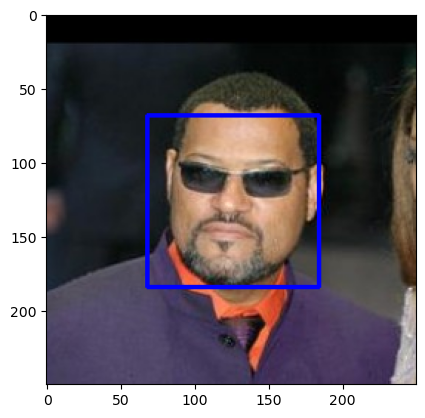

```python
import cv2
import matplotlib.pyplot as plt
%matplotlib inline

# extract pre-trained face detector
face_cascade = cv2.CascadeClassifier('haarcascades/haarcascade_frontalface_alt.xml')

# load color (BGR) image
img = cv2.imread(human_files[3])
# convert BGR image to grayscale
gray = cv2.cvtColor(img, cv2.COLOR_BGR2GRAY)

# find faces in image
faces = face_cascade.detectMultiScale(gray)
#print(faces)

# print number of faces detected in the image
print('Number of faces detected:', len(faces))

# get bounding box for each detected face
for (x,y,w,h) in faces:
    # add bounding box to color image
    cv2.rectangle(img,(x,y),(x+w,y+h),(255,0,0),2)

# convert BGR image to RGB for plotting
cv_rgb = cv2.cvtColor(img, cv2.COLOR_BGR2RGB)

# display the image, along with bounding box
plt.imshow(cv_rgb)
plt.show()
```

Before using any of the face detectors, it is standard procedure to convert the images to grayscale. The `detectMultiScale` function executes the classifier stored in `face_cascade` and takes the grayscale image as a parameter.

In the above code, `faces` is a numpy array of detected faces, where each row corresponds to a detected face. Each detected face is a 1D array with four entries that specifies the bounding box of the detected face. The first two entries in the array (extracted in the above code as `x` and `y`) specify the horizontal and vertical positions of the top left corner of the bounding box. The last two entries in the array (extracted here as `w` and `h`) specify the width and height of the box.

### Write a Human Face Detector

We can use this procedure to write a function that returns `True` if a human face is detected in an image and `False` otherwise. This function, aptly named `face_detector`, takes a string-valued file path to an image as input and appears in the code block below.

```python
# returns "True" if face is detected in image stored at img_path
def face_detector(img_path):
    img = cv2.imread(img_path)
    gray = cv2.cvtColor(img, cv2.COLOR_BGR2GRAY)
    faces = face_cascade.detectMultiScale(gray)
    return len(faces) > 0
```

### (IMPLEMENTATION) Assess the Human Face Detector

**Question 1:** Use the code cell below to test the performance of the `face_detector` function.

- What percentage of the first 100 images in `human_files` have a detected human face?
- What percentage of the first 100 images in `dog_files` have a detected human face?

Ideally, we would like 100% of human images with a detected face and 0% of dog images with a detected face. You will see that our algorithm falls short of this goal, but still gives acceptable performance. We extract the file paths for the first 100 images from each of the datasets and store them in the numpy arrays `human_files_short` and `dog_files_short`.

**Answer:**

```python
human_files_short = human_files[:100]
dog_files_short = train_files[:100]
# Do NOT modify the code above this line.
```

```python
human_files_short = human_files[:100]
dog_files_short = train_files[:100]
# Do NOT modify the code above this line.

human_results = []
for file in human_files_short:
    human_results.append(face_detector(file))

#print(human_results)
human_anzahl_true = human_results.count(True)
percentage_correct_classification_human = 100/human_files_short.size*human_anzahl_true
print(f'{percentage_correct_classification_human} % der Menschen wurde als Mensch klassifiziert')

dog_results = []
for file in dog_files_short:
    dog_results.append(face_detector(file))

#print(dog_results)
dog_anzahl_true = dog_results.count(True)
percentage_correct_classification_dog = 100/dog_files_short.size*dog_anzahl_true
print(f'{percentage_correct_classification_dog} % der Hunde wurde als Mensch klassifiziert')



## TODO: Test the performance of the face_detector algorithm
## on the images in human_files_short and dog_files_short.
```

```
100.0 % der Menschen wurde als Mensch klassifiziert
12.0 % der Hunde wurde als Mensch klassifiziert
```

```python
# Wie viele aus dem gasamten human_files DS werden als Menschen erkannt?

human_results = []
for file in human_files:
    human_results.append(face_detector(file))

#print(human_results)
human_anzahl_true = human_results.count(True)
percentage_correct_classification_human = 100/human_files.size*human_anzahl_true
print(f'{percentage_correct_classification_human} % der Menschen wurde als Mensch klassifiziert')
```

```
98.72288974533363 % der Menschen wurde als Mensch klassifiziert
```

**Question 2:** This algorithmic choice necessitates that we communicate to the user that we accept human images only when they provide a clear view of a face (otherwise, we risk having unneccessarily frustrated users!). In your opinion, is this a reasonable expectation to pose on the user? If not, can you think of a way to detect humans in images that does not necessitate an image with a clearly presented face?

**Answer:** I think this is not a reasonable expectation. Therefore I investigated for a better algorithm and found the MTCC https://pypi.org/project/mtcnn/)

We suggest the face detector from OpenCV as a potential way to detect human images in your algorithm, but you are free to explore other approaches, especially approaches that make use of deep learning :). Please use the code cell below to design and test your own face detection algorithm. If you decide to pursue this *optional* task, report performance on each of the datasets.

```python
## (Optional) TODO: Report the performance of another
## face detection algorithm on the LFW dataset
### Feel free to use as many code cells as needed.
```

```python
# Install MTCNN (Multi-Task Cascaded Convolutional Networks) for face recognition,
# to improve the recognition of faces which do not look directly into the camera.
!python3 -m pip install mtcnn
```

[output not shown]

```python
# Install tensorflow if it is not allready installed on the machine
!python3 -m pip install tensorflow
```

```python
# Import pre-trained model for face recognition from MTCNN Python Package (PyPI) (https://pypi.org/project/mtcnn/)

from mtcnn import MTCNN

def is_face_detected(image_path, show_image=False):
    # Lade das Bild und konvertiere es in RGB
    image = cv2.cvtColor(cv2.imread(image_path), cv2.COLOR_BGR2RGB)

    # Erstelle ein MTCNN-Objekt
    detector = MTCNN()

    # Erkenne Gesichter im Bild
    faces = detector.detect_faces(image)

    # Wenn mindestens ein Gesicht erkannt wurde, ist is_face True
    is_face = len(faces) > 0

    # Zeichne erkannte Gesichter und zeige das Bild an
    if show_image and is_face:
        for face in faces:
            # Hole die Koordinaten des Bounding-Boxes
            x, y, width, height = face['box']
            # Zeichne ein Rechteck um das Gesicht
            cv2.rectangle(image, (x, y), (x + width, y + height), (0, 255, 0), 2)

        # Anzeige des Bildes mit den erkannten Gesichtern
        plt.imshow(image)
        plt.axis("off")
        plt.show()

    return is_face
```

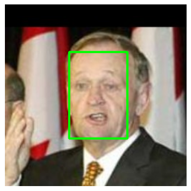

```
Gesicht erkannt!
```

```python
human_files_short = human_files[:100]
dog_files_short = train_files[:100]

face_detected = is_face_detected(human_files_short[76], show_image=True)

if face_detected:
    print("Gesicht erkannt!")
else:
    print("Kein Gesicht erkannt.")
```

```python
human_files_short = human_files[:100]
dog_files_short = train_files[:100]
# Do NOT modify the code above this line.

human_results = []
for file in human_files_short:
    human_results.append(is_face_detected(file))

#print(human_results)
human_anzahl_true = human_results.count(True)
percentage_correct_classification_human = 100/human_files_short.size*human_anzahl_true
print(f'{percentage_correct_classification_human} % der Menschen wurde als Mensch klassifiziert')
```

```
100.0 % der Menschen wurde als Mensch klassifiziert
```

```python
dog_results = []
for file in dog_files_short:
    dog_results.append(is_face_detected(file))

#print(dog_results)
dog_anzahl_true = dog_results.count(True)
percentage_correct_classification_dog = 100/dog_files_short.size*dog_anzahl_true
print(f'{percentage_correct_classification_dog} % der Hunde wurde als Mensch klassifiziert')
```

```
19.0 % der Hunde wurde als Mensch klassifiziert
```

Detection of MTCNN on the complete dog and human Dataset

```python
#This takes to long, the kernal broke in the Udacity Jupyter environment with activated GPU.
# Also on my local machine it would take to long to run.

def percentage_of_human_detected(picture_files):
    # List comprehension to collect results
    results = [is_face_detected(file) for file in picture_files]

    # Count the number of True values directly using sum
    anzahl_true = sum(results)

    # Calculate the percentage directly
    percentage_classification_human = (anzahl_true / len(picture_files)) * 100

    return percentage_classification_human

# Optimized way to calculate percentages for different datasets
datasets = {
    "train_files": train_files,
    "valid_files": valid_files,
    "test_files": test_files,
    "human_files": human_files
}

for key, files in datasets.items():
    percentage = percentage_of_human_detected(files)
    if key == "human_files":
        print(f'{percentage} % der Menschen im gesamten Menschen Datensatz wurde als Mensch klassifiziert')
    else:
        print(f'{percentage} % der Hunde im {key.replace("_files", "")} Datensatz wurde als Mensch klassifiziert')
```

```
14.681647940074907 % der Hunde im train Datensatz wurde als Mensch klassifiziert
15.089820359281436 % der Hunde im valid Datensatz wurde als Mensch klassifiziert
13.532934131736527 % der Hunde im test Datensatz wurde als Mensch klassifiziert
99.99244313458777 % der Menschen im gesamten Menschen Datensatz wurde als Mensch klassifiziert
```

##### Output from above stored into seperate cell since calculaion time was 2 days.

- 14.68 % der Hunde im train Datensatz wurde als Mensch klassifiziert
- 15.09 % der Hunde im valid Datensatz wurde als Mensch klassifiziert
- 13.53 % der Hunde im test Datensatz wurde als Mensch klassifiziert
- 99.99 % der Menschen im gesamten Menschen Datensatz wurde als Mensch klassifiziert

## Step 2: Detect Dogs

In this section, we use a pre-trained [ResNet-50](http://ethereon.github.io/netscope/#/gist/db945b393d40bfa26006) model to detect dogs in images. Our first line of code downloads the ResNet-50 model, along with weights that have been trained on [ImageNet](http://www.image-net.org/), a very large, very popular dataset used for image classification and other vision tasks. ImageNet contains over 10 million URLs, each linking to an image containing an object from one of [1000 categories](https://gist.github.com/yrevar/942d3a0ac09ec9e5eb3a). Given an image, this pre-trained ResNet-50 model returns a prediction (derived from the available categories in ImageNet) for the object that is contained in the image.

```python
from keras.applications.resnet50 import ResNet50

# define ResNet50 model
ResNet50_model = ResNet50(weights='imagenet')
```

### Pre-process the Data

When using TensorFlow as backend, Keras CNNs require a 4D array (which we'll also refer to as a 4D tensor) as input, with shape

$$ (\text{nb_samples}, \text{rows}, \text{columns}, \text{channels}), $$

where `nb_samples` corresponds to the total number of images (or samples), and `rows`, `columns`, and `channels` correspond to the number of rows, columns, and channels for each image, respectively.

The `path_to_tensor` function below takes a string-valued file path to a color image as input and returns a 4D tensor suitable for supplying to a Keras CNN. The function first loads the image and resizes it to a square image that is $224 \times 224$ pixels. Next, the image is converted to an array, which is then resized to a 4D tensor. In this case, since we are working with color images, each image has three channels. Likewise, since we are processing a single image (or sample), the returned tensor will always have shape

$$ (1, 224, 224, 3). $$

The `paths_to_tensor` function takes a numpy array of string-valued image paths as input and returns a 4D tensor with shape

$$ (\text{nb_samples}, 224, 224, 3). $$

Here, `nb_samples` is the number of samples, or number of images, in the supplied array of image paths. It is best to think of `nb_samples` as the number of 3D tensors (where each 3D tensor corresponds to a different image) in your dataset!

Ein einzelnes Bild hat der Tensor die Form (1, 224, 224, 3) — wobei 1 für das eine Bildbeispiel steht, 224x224 die räumlichen Dimensionen darstellen und 3 die Farbebenen (RGB) sind.

```python
from keras.preprocessing import image
from tqdm import tqdm

# Nimmt einen Pfad zu einer Bilddatei als Eingabe und wandelt ihn in einen geeigneten 4D-Tensor um.
def path_to_tensor(img_path):
    try:
        img = image.load_img(img_path, target_size=(224, 224))
        x = image.img_to_array(img)
        # Normalize the image tensor is not required since it is done in the preprocess_input!
        return np.expand_dims(x, axis=0)
    except IOError:
        print(f"Warning: Skipping corrupted image {img_path}")
        return None

def paths_to_tensor(img_paths):
    batch_tensors = []
    for img_path in img_paths:
        tensor = path_to_tensor(img_path)
        if tensor is not None:
            batch_tensors.append(tensor[0])
    return np.array(batch_tensors)
```

```python
#Test
resulting_tensor = path_to_tensor(human_files_short[1])
print(resulting_tensor.shape)

resulting_tensor = paths_to_tensor(human_files_short)
print(resulting_tensor.shape)
```

```
(1, 224, 224, 3)
(100, 224, 224, 3)
```

### Making Predictions with ResNet-50

Getting the 4D tensor ready for ResNet-50, and for any other pre-trained model in Keras, requires some additional processing. First, the RGB image is converted to BGR by reordering the channels. All pre-trained models have the additional normalization step that the mean pixel (expressed in RGB as $[103.939, 116.779, 123.68]$ and calculated from all pixels in all images in ImageNet) must be subtracted from every pixel in each image. This is implemented in the imported function `preprocess_input`. If you're curious, you can check the code for `preprocess_input` [here](https://github.com/fchollet/keras/blob/master/keras/applications/imagenet_utils.py).

Now that we have a way to format our image for supplying to ResNet-50, we are now ready to use the model to extract the predictions. This is accomplished with the `predict` method, which returns an array whose $i$-th entry is the model's predicted probability that the image belongs to the $i$-th ImageNet category. This is implemented in the `ResNet50_predict_labels` function below.

By taking the argmax of the predicted probability vector, we obtain an integer corresponding to the model's predicted object class, which we can identify with an object category through the use of this [dictionary](https://gist.github.com/yrevar/942d3a0ac09ec9e5eb3a).

```python
from keras.applications.resnet50 import preprocess_input, decode_predictions

def ResNet50_predict_labels(img_path):
    # returns prediction vector for image located at img_path
    img = preprocess_input(path_to_tensor(img_path)) # RGB-Bild --> BGR umgewandelt und dann normalisiert,
    return np.argmax(ResNet50_model.predict(img)) # argmax: Ganzzahl, die der Klasse des vorhergesagten Objekts entspricht
```

### Write a Dog Detector

While looking at the [dictionary](https://gist.github.com/yrevar/942d3a0ac09ec9e5eb3a), you will notice that the categories corresponding to dogs appear in an uninterrupted sequence and correspond to dictionary keys 151-268, inclusive, to include all categories from `'Chihuahua'` to `'Mexican hairless'`. Thus, in order to check to see if an image is predicted to contain a dog by the pre-trained ResNet-50 model, we need only check if the `ResNet50_predict_labels` function above returns a value between 151 and 268 (inclusive).

We use these ideas to complete the `dog_detector` function below, which returns `True` if a dog is detected in an image (and `False` if not).

```python
### returns "True" if a dog is detected in the image stored at img_path
def dog_detector(img_path):
    prediction = ResNet50_predict_labels(img_path)
    return ((prediction <= 268) & (prediction >= 151))
```

### (IMPLEMENTATION) Assess the Dog Detector

**Question 3:** Use the code cell below to test the performance of your `dog_detector` function.

- What percentage of the images in `human_files_short` have a detected dog?
- What percentage of the images in `dog_files_short` have a detected dog?

**Answer:**

```python
img_path = "D:/GIT/Assignement7/human_files_directory/Svetlana_Koroleva_0002.jpg"
img_path2 = "D:/GIT/Assignement7/human_files_directory\Yoko_Ono_0001.jpg"
if dog_detector(img_path):
    print("Hund erkannt!")
else:
    print("Kein Hund erkannt.")
```

```
1/1 ━━━━━━━━━━━━━━━━━━━━ 2s 2s/step
Kein Hund erkannt.
```

```
1/1 ━━━━━━━━━━━━━━━━━━━━ 0s 207ms/step
Für D:/GIT/Assignement7/human_files_directory\Svetlana_Koroleva_0002.jpg keinen Hund erkannt.
```

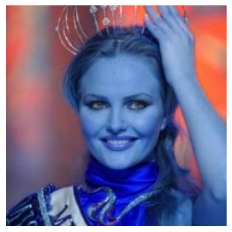

```python
### TODO: Test the performance of the dog_detector function
### on the images in human_files_short and dog_files_short.


img_path = human_files_short[2]

if dog_detector(img_path):
    print(f"Für {img_path} einen Hund erkannt!")
else:
    print(f"Für {img_path} keinen Hund erkannt.")

picture = cv2.imread(img_path)
plt.imshow(picture)
plt.axis("off")
plt.show()
```

```
1/1 ━━━━━━━━━━━━━━━━━━━━ 0s 281ms/step
Für D:/GIT/Assignement7/dog_images_complete/dogImages/train\057.Dalmatian\Dalmatian_04054.jpg einen Hund erkannt!
```

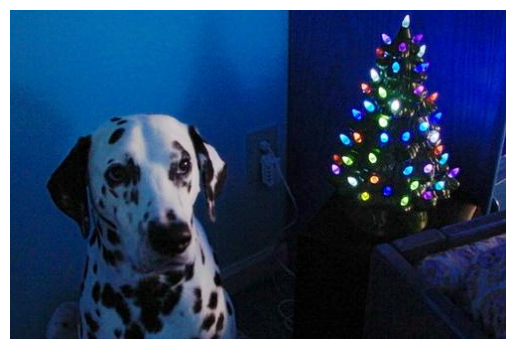

```python
img_path = dog_files_short[1]

if dog_detector(img_path):
    print(f"Für {img_path} einen Hund erkannt!")
else:
    print(f"Für {img_path} keinen Hund erkannt.")

picture = cv2.imread(img_path)
plt.imshow(picture)
plt.axis("off")
plt.show()
```

```python
predicted_dogs = []
for image_path in human_files_short:
    #print(image)
    predicted_dogs.append(dog_detector(image_path))

number_predicted_dogs = predicted_dogs.count(True)
number_human_files = len(human_files_short)
print(f'From {number_human_files} human faces, there were {number_predicted_dogs} predicted as dogs')
```

[output not shown]

[output cut: 46 more lines]

[output not shown]

```python
predicted_dogs = []
for image_path in dog_files_short:
    #print(image)
    predicted_dogs.append(dog_detector(image_path))

number_predicted_dogs = predicted_dogs.count(True)
number_dog_files = len(dog_files_short)
print(f'From {number_dog_files} dogs, there were {number_predicted_dogs} predicted as dogs')
```

[output not shown]

[output cut: 46 more lines]

[output not shown]

## Step 3: Create a CNN to Classify Dog Breeds (from Scratch)

Now that we have functions for detecting humans and dogs in images, we need a way to predict breed from images. In this step, you will create a CNN that classifies dog breeds. You must create your CNN *from scratch* (so, you can't use transfer learning *yet*!), and you must attain a test accuracy of at least 1%. In Step 5 of this notebook, you will have the opportunity to use transfer learning to create a CNN that attains greatly improved accuracy.

Be careful with adding too many trainable layers! More parameters means longer training, which means you are more likely to need a GPU to accelerate the training process. Thankfully, Keras provides a handy estimate of the time that each epoch is likely to take; you can extrapolate this estimate to figure out how long it will take for your algorithm to train.

We mention that the task of assigning breed to dogs from images is considered exceptionally challenging. To see why, consider that *even a human* would have great difficulty in distinguishing between a Brittany and a Welsh Springer Spaniel.

| Brittany | Welsh Springer Spaniel |
| --- | --- |

It is not difficult to find other dog breed pairs with minimal inter-class variation (for instance, Curly-Coated Retrievers and American Water Spaniels).

| Curly-Coated Retriever | American Water Spaniel |
| --- | --- |

Likewise, recall that labradors come in yellow, chocolate, and black. Your vision-based algorithm will have to conquer this high intra-class variation to determine how to classify all of these different shades as the same breed.

| Yellow Labrador | Chocolate Labrador | Black Labrador |
| --- | --- | --- |

We also mention that random chance presents an exceptionally low bar: setting aside the fact that the classes are slightly imabalanced, a random guess will provide a correct answer roughly 1 in 133 times, which corresponds to an accuracy of less than 1%.

Remember that the practice is far ahead of the theory in deep learning. Experiment with many different architectures, and trust your intuition. And, of course, have fun!

### Pre-process the Data

We rescale the images by dividing every pixel in every image by 255.

```python
from PIL import ImageFile
ImageFile.LOAD_TRUNCATED_IMAGES = True  # Allow loading of truncated images

def image_generator(files, targets, batch_size):
    while True:
        batch_paths = np.random.choice(a=files, size=batch_size)
        batch_input = paths_to_tensor(batch_paths)
        valid_paths = [p for p in batch_paths if path_to_tensor(p) is not None]
        batch_indices = [np.where(files == img_path)[0][0] for img_path in valid_paths]
        batch_output = np.array([targets[index] for index in batch_indices])

        if len(batch_input) > 0:  # Ensure there is data to yield
            yield batch_input, batch_output

# Create generators for train, validation, and test datasets
train_generator = image_generator(train_files, train_targets, batch_size=64)
valid_generator = image_generator(valid_files, valid_targets, batch_size=64)
test_generator = image_generator(test_files, test_targets, batch_size=64)
```

### (IMPLEMENTATION) Model Architecture

Create a CNN to classify dog breed. At the end of your code cell block, summarize the layers of your model by executing the line:

```
    model.summary()
```

We have imported some Python modules to get you started, but feel free to import as many modules as you need. If you end up getting stuck, here's a hint that specifies a model that trains relatively fast on CPU and attains >1% test accuracy in 5 epochs:

[figure not shown]

**Question 4:** Outline the steps you took to get to your final CNN architecture and your reasoning at each step. If you chose to use the hinted architecture above, describe why you think that CNN architecture should work well for the image classification task.

**Answer:**

I choose the following architecture for the CNN.

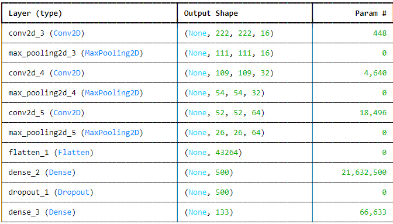

- Convolutional layers (Conv2D) extract features such as edges, colors, and complex patterns.
- Pooling layers (MaxPooling2D) reduce the spatial size of the features to prevent overfitting and optimize computational performance.
- Flatten converts the feature maps into a format that can be processed by fully connected layers.
- Fully connected layers (Dense) learn the relationships between the extracted features and help in classification.
- Dropout is added to prevent overfitting.
- The Softmax layer outputs the probabilities for each of the 133 dog breeds.

I started with a small convolutional layer to extract 16 parameters from the 3x3 pixel and then in the second and third convolutional layer extended the parameters to 32 and 64 to extract more complex features from the picture. In between each convolutional layer I added pooling Layers since they are useful to reduce the number of parameters and so to increase efficiency of the model as well as reduce the risk of overfitting. Moreover I use a layer to flatten the the output from the convolutional layers to be able to feed it into a fully connected layer. I use two dense layer to process the features from the previous layers. In between the dense layer I inserted dropout layer to reduce the risk of overfitting and to improve the generalization possibility of the network. As activation functions I choose the relu function except for the last layer where I use a softmax function for the classification task. The relu function introduces non-linearities and improves training. The softmax function provites a probability which is over all outputs a sum of one, so we get the probability for each dog breed.

#### Aufbau CNN

- Convolutional Layers (Conv2D) extrahieren Merkmale wie Kanten, Farben und komplexe Muster.
- Pooling Layers (MaxPooling2D) reduzieren die räumliche Größe der Merkmale, um Überanpassung zu vermeiden und die Rechenleistung zu optimieren.
- Flatten konvertiert die Feature Maps in eine Form, die von den vollständig verbundenen Schichten verarbeitet werden kann.
- Fully Connected Layers (Dense) lernen die Beziehungen zwischen den extrahierten Merkmalen und helfen bei der Klassifizierung.
- Dropout wird hinzugefügt, um Überanpassung zu verhindern.
- Die Softmax-Schicht gibt die Wahrscheinlichkeiten für jede der 133 Hunderassen zurück.

```python
from keras.layers import Conv2D, MaxPooling2D, GlobalAveragePooling2D
from keras.layers import Dropout, Flatten, Dense
from keras.models import Sequential

model = Sequential()

### TODO: Define your architecture.

# CNN-Modell zur Klassifizierung von Hunderassen
model = Sequential()

# Erste Convolutional Schicht und Pooling Schicht
model.add(Conv2D(16, (3, 3), activation='relu', input_shape=(224, 224, 3)))
model.add(MaxPooling2D(pool_size=(2, 2)))

# Zweite Convolutional Schicht und Pooling Schicht
model.add(Conv2D(32, (3, 3), activation='relu'))
model.add(MaxPooling2D(pool_size=(2, 2)))

# Dritte Convolutional Schicht und Pooling Schicht
model.add(Conv2D(64, (3, 3), activation='relu'))
model.add(MaxPooling2D(pool_size=(2, 2)))

# Flatten (Umwandlung der 2D-Daten in 1D) und vollständig verbundene Schichten
model.add(Flatten())
model.add(Dense(500, activation='relu'))
model.add(Dropout(0.5))  # Dropout, um Überanpassung zu vermeiden
model.add(Dense(133, activation='softmax'))  # 133 Klassen (Hunderassen)

# Modellübersicht
model.summary()
```

```
Model: "sequential_1"
```

```
┏━━━━━━━━━━━━━━━━━━━━━━━━━━━━━━━━━━━━━━┳━━━━━━━━━━━━━━━━━━━━━━━━━━━━━┳━━━━━━━━━━━━━━━━━┓
┃ Layer (type)                         ┃ Output Shape                ┃         Param # ┃
┡━━━━━━━━━━━━━━━━━━━━━━━━━━━━━━━━━━━━━━╇━━━━━━━━━━━━━━━━━━━━━━━━━━━━━╇━━━━━━━━━━━━━━━━━┩
│ conv2d (Conv2D)                      │ (None, 222, 222, 16)        │             448 │
├──────────────────────────────────────┼─────────────────────────────┼─────────────────┤
│ max_pooling2d (MaxPooling2D)         │ (None, 111, 111, 16)        │               0 │
├──────────────────────────────────────┼─────────────────────────────┼─────────────────┤
│ conv2d_1 (Conv2D)                    │ (None, 109, 109, 32)        │           4,640 │
├──────────────────────────────────────┼─────────────────────────────┼─────────────────┤
│ max_pooling2d_1 (MaxPooling2D)       │ (None, 54, 54, 32)          │               0 │
├──────────────────────────────────────┼─────────────────────────────┼─────────────────┤
│ conv2d_2 (Conv2D)                    │ (None, 52, 52, 64)          │          18,496 │
├──────────────────────────────────────┼─────────────────────────────┼─────────────────┤
│ max_pooling2d_2 (MaxPooling2D)       │ (None, 26, 26, 64)          │               0 │
├──────────────────────────────────────┼─────────────────────────────┼─────────────────┤
│ flatten (Flatten)                    │ (None, 43264)               │               0 │
├──────────────────────────────────────┼─────────────────────────────┼─────────────────┤
│ dense (Dense)                        │ (None, 500)                 │      21,632,500 │
├──────────────────────────────────────┼─────────────────────────────┼─────────────────┤
│ dropout (Dropout)                    │ (None, 500)                 │               0 │
├──────────────────────────────────────┼─────────────────────────────┼─────────────────┤
│ dense_1 (Dense)                      │ (None, 133)                 │          66,633 │
└──────────────────────────────────────┴─────────────────────────────┴─────────────────┘
```

```
 Total params: 21,722,717 (82.87 MB)
```

```
 Trainable params: 21,722,717 (82.87 MB)
```

```
 Non-trainable params: 0 (0.00 B)
```

### Compile the Model

```python
from keras.optimizers import Adam

# Set a smaller learning rate
adam = Adam(learning_rate =0.001)
model.compile(optimizer=adam, loss='categorical_crossentropy', metrics=['accuracy'])
```

### (IMPLEMENTATION) Train the Model

Train your model in the code cell below. Use model checkpointing to save the model that attains the best validation loss.

You are welcome to [augment the training data](https://blog.keras.io/building-powerful-image-classification-models-using-very-little-data.html), but this is not a requirement.

```python
from keras.callbacks import ModelCheckpoint, ReduceLROnPlateau

### TODO: specify the number of epochs that you would like to use to train the model.

epochs = 5

### Do NOT modify the code below this line.

# Add checkpoint to save the best model
checkpointer = ModelCheckpoint(filepath='saved_models/weights.best.from_scratch.keras',
                               verbose=1, save_best_only=True)

# ReduceLROnPlateau: This callback reduces the learning rate when a metric has stopped improving.
reduce_lr = ReduceLROnPlateau(monitor='val_loss', factor=0.1, patience=5)

# Train the model
model.fit(train_generator,
          steps_per_epoch=len(train_files) // 32,
          validation_data=valid_generator,
          validation_steps=len(valid_files) // 32,
          epochs=epochs,
          callbacks=[checkpointer, reduce_lr],
          verbose=2)
```

```
Epoch 1: val_loss improved from inf to 5.28326, saving model to saved_models/weights.best.from_scratch.keras
208/208 - 456s - 2s/step - accuracy: 0.2302 - loss: 9.7747 - val_accuracy: 0.0312 - val_loss: 5.2833 - learning_rate: 0.0010

Epoch 2: val_loss did not improve from 5.28326
208/208 - 407s - 2s/step - accuracy: 0.6199 - loss: 1.9691 - val_accuracy: 0.0373 - val_loss: 5.8711 - learning_rate: 0.0010

Epoch 3: val_loss did not improve from 5.28326
208/208 - 415s - 2s/step - accuracy: 0.8199 - loss: 0.8768 - val_accuracy: 0.0240 - val_loss: 6.8023 - learning_rate: 0.0010

Epoch 4: val_loss did not improve from 5.28326
208/208 - 408s - 2s/step - accuracy: 0.8937 - loss: 0.4967 - val_accuracy: 0.0312 - val_loss: 7.3336 - learning_rate: 0.0010

Epoch 5: val_loss did not improve from 5.28326
208/208 - 397s - 2s/step - accuracy: 0.9239 - loss: 0.3454 - val_accuracy: 0.0282 - val_loss: 8.1166 - learning_rate: 0.0010
```

```
<keras.src.callbacks.history.History at 0x2971e997a60>
```

### Load the Model with the Best Validation Loss

```python
model.load_weights('saved_models/weights.best.from_scratch.keras')
```

### Test the Model

Try out your model on the test dataset of dog images. Ensure that your test accuracy is greater than 1%.

```python
# Evaluate the model on the test data using `evaluate_generator`
test_loss, test_accuracy = model.evaluate(test_generator, steps=len(test_files) // 32)

# Convert the accuracy to percentage
test_accuracy = test_accuracy * 100

print('Test accuracy: %.4f%%' % test_accuracy)
```

```
26/26 ━━━━━━━━━━━━━━━━━━━━ 23s 904ms/step - accuracy: 0.0187 - loss: 5.2256
Test accuracy: 2.4639%
```

## Step 4: Use a CNN to Classify Dog Breeds

To reduce training time without sacrificing accuracy, we show you how to train a CNN using transfer learning. In the following step, you will get a chance to use transfer learning to train your own CNN.

### Obtain Bottleneck Features

```python
bottleneck_features = np.load('bottleneck_features/DogVGG16Data.npz')

train_VGG16 = bottleneck_features['train']
valid_VGG16 = bottleneck_features['valid']
test_VGG16 = bottleneck_features['test']
```

### Model Architecture

The model uses the the pre-trained VGG-16 model as a fixed feature extractor, where the last convolutional output of VGG-16 is fed as input to our model. We only add a global average pooling layer and a fully connected layer, where the latter contains one node for each dog category and is equipped with a softmax.

```python
VGG16_model = Sequential()
VGG16_model.add(GlobalAveragePooling2D(input_shape=train_VGG16.shape[1:]))
VGG16_model.add(Dense(133, activation='softmax'))

VGG16_model.summary()
```

```
Model: "sequential_2"
```

```
┏━━━━━━━━━━━━━━━━━━━━━━━━━━━━━━━━━━━━━━┳━━━━━━━━━━━━━━━━━━━━━━━━━━━━━┳━━━━━━━━━━━━━━━━━┓
┃ Layer (type)                         ┃ Output Shape                ┃         Param # ┃
┡━━━━━━━━━━━━━━━━━━━━━━━━━━━━━━━━━━━━━━╇━━━━━━━━━━━━━━━━━━━━━━━━━━━━━╇━━━━━━━━━━━━━━━━━┩
│ global_average_pooling2d             │ (None, 512)                 │               0 │
│ (GlobalAveragePooling2D)             │                             │                 │
├──────────────────────────────────────┼─────────────────────────────┼─────────────────┤
│ dense_2 (Dense)                      │ (None, 133)                 │          68,229 │
└──────────────────────────────────────┴─────────────────────────────┴─────────────────┘
```

```
 Total params: 68,229 (266.52 KB)
```

```
 Trainable params: 68,229 (266.52 KB)
```

```
 Non-trainable params: 0 (0.00 B)
```

### Compile the Model

```python
VGG16_model.compile(loss='categorical_crossentropy', optimizer='rmsprop', metrics=['accuracy'])
```

### Train the Model

```python
from keras.callbacks import ModelCheckpoint, ReduceLROnPlateau

checkpointer = ModelCheckpoint(filepath='saved_models/weights.best.VGG16.keras',
                               verbose=1, save_best_only=True)

print("Train shape", train_VGG16.shape, train_targets.shape)
print("Validate shape", valid_VGG16.shape, valid_targets.shape)

VGG16_model.fit(train_VGG16, train_targets,
          validation_data=(valid_VGG16, valid_targets),
          epochs=20, batch_size=20, callbacks=[checkpointer], verbose=1)
```

```
Train shape (6680, 7, 7, 512) (6680, 133)
Validate shape (835, 7, 7, 512) (835, 133)
317/334 ━━━━━━━━━━━━━━━━━━━━ 0s 3ms/step - accuracy: 0.0983 - loss: 12.7387
Epoch 1: val_loss improved from inf to 3.73462, saving model to saved_models/weights.best.VGG16.keras
334/334 ━━━━━━━━━━━━━━━━━━━━ 2s 4ms/step - accuracy: 0.1049 - loss: 12.4911 - val_accuracy: 0.4144 - val_loss: 3.7346
323/334 ━━━━━━━━━━━━━━━━━━━━ 0s 3ms/step - accuracy: 0.5593 - loss: 2.4386
Epoch 2: val_loss improved from 3.73462 to 2.50353, saving model to saved_models/weights.best.VGG16.keras
334/334 ━━━━━━━━━━━━━━━━━━━━ 2s 3ms/step - accuracy: 0.5601 - loss: 2.4329 - val_accuracy: 0.5844 - val_loss: 2.5035
332/334 ━━━━━━━━━━━━━━━━━━━━ 0s 3ms/step - accuracy: 0.7250 - loss: 1.2712
Epoch 3: val_loss improved from 2.50353 to 2.07707, saving model to saved_models/weights.best.VGG16.keras
334/334 ━━━━━━━━━━━━━━━━━━━━ 1s 4ms/step - accuracy: 0.7251 - loss: 1.2708 - val_accuracy: 0.6395 - val_loss: 2.0771
328/334 ━━━━━━━━━━━━━━━━━━━━ 0s 3ms/step - accuracy: 0.8085 - loss: 0.8103
Epoch 4: val_loss improved from 2.07707 to 1.98506, saving model to saved_models/weights.best.VGG16.keras
334/334 ━━━━━━━━━━━━━━━━━━━━ 1s 4ms/step - accuracy: 0.8086 - loss: 0.8105 - val_accuracy: 0.6599 - val_loss: 1.9851
319/334 ━━━━━━━━━━━━━━━━━━━━ 0s 3ms/step - accuracy: 0.8771 - loss: 0.5115
Epoch 5: val_loss improved from 1.98506 to 1.87595, saving model to saved_models/weights.best.VGG16.keras
334/334 ━━━━━━━━━━━━━━━━━━━━ 1s 4ms/step - accuracy: 0.8763 - loss: 0.5145 - val_accuracy: 0.6850 - val_loss: 1.8759
320/334 ━━━━━━━━━━━━━━━━━━━━ 0s 3ms/step - accuracy: 0.9039 - loss: 0.3436
Epoch 6: val_loss improved from 1.87595 to 1.81395, saving model to saved_models/weights.best.VGG16.keras
334/334 ━━━━━━━━━━━━━━━━━━━━ 1s 3ms/step - accuracy: 0.9034 - loss: 0.3463 - val_accuracy: 0.6922 - val_loss: 1.8140
325/334 ━━━━━━━━━━━━━━━━━━━━ 0s 3ms/step - accuracy: 0.9247 - loss: 0.2762
Epoch 7: val_loss did not improve from 1.81395
334/334 ━━━━━━━━━━━━━━━━━━━━ 2s 4ms/step - accuracy: 0.9245 - loss: 0.2769 - val_accuracy: 0.6970 - val_loss: 1.8815
328/334 ━━━━━━━━━━━━━━━━━━━━ 0s 3ms/step - accuracy: 0.9413 - loss: 0.1993
Epoch 8: val_loss improved from 1.81395 to 1.68468, saving model to saved_models/weights.best.VGG16.keras
334/334 ━━━━━━━━━━━━━━━━━━━━ 1s 3ms/step - accuracy: 0.9412 - loss: 0.1997 - val_accuracy: 0.6994 - val_loss: 1.6847
322/334 ━━━━━━━━━━━━━━━━━━━━ 0s 3ms/step - accuracy: 0.9620 - loss: 0.1307
Epoch 9: val_loss did not improve from 1.68468
334/334 ━━━━━━━━━━━━━━━━━━━━ 1s 3ms/step - accuracy: 0.9615 - loss: 0.1323 - val_accuracy: 0.7210 - val_loss: 1.7827
320/334 ━━━━━━━━━━━━━━━━━━━━ 0s 3ms/step - accuracy: 0.9668 - loss: 0.1091
Epoch 10: val_loss did not improve from 1.68468
334/334 ━━━━━━━━━━━━━━━━━━━━ 1s 3ms/step - accuracy: 0.9665 - loss: 0.1099 - val_accuracy: 0.7102 - val_loss: 1.8365
330/334 ━━━━━━━━━━━━━━━━━━━━ 0s 3ms/step - accuracy: 0.9731 - loss: 0.1003
Epoch 11: val_loss did not improve from 1.68468
334/334 ━━━━━━━━━━━━━━━━━━━━ 1s 4ms/step - accuracy: 0.9731 - loss: 0.1003 - val_accuracy: 0.7257 - val_loss: 1.7768
333/334 ━━━━━━━━━━━━━━━━━━━━ 0s 4ms/step - accuracy: 0.9777 - loss: 0.0657
Epoch 12: val_loss did not improve from 1.68468
334/334 ━━━━━━━━━━━━━━━━━━━━ 2s 4ms/step - accuracy: 0.9777 - loss: 0.0658 - val_accuracy: 0.7353 - val_loss: 1.8602
316/334 ━━━━━━━━━━━━━━━━━━━━ 0s 4ms/step - accuracy: 0.9832 - loss: 0.0621
Epoch 13: val_loss did not improve from 1.68468
334/334 ━━━━━━━━━━━━━━━━━━━━ 2s 4ms/step - accuracy: 0.9831 - loss: 0.0621 - val_accuracy: 0.7317 - val_loss: 1.8850
331/334 ━━━━━━━━━━━━━━━━━━━━ 0s 3ms/step - accuracy: 0.9871 - loss: 0.0343
Epoch 14: val_loss did not improve from 1.68468
334/334 ━━━━━━━━━━━━━━━━━━━━ 1s 3ms/step - accuracy: 0.9871 - loss: 0.0345 - val_accuracy: 0.7222 - val_loss: 1.7973
316/334 ━━━━━━━━━━━━━━━━━━━━ 0s 3ms/step - accuracy: 0.9903 - loss: 0.0296
Epoch 15: val_loss did not improve from 1.68468
334/334 ━━━━━━━━━━━━━━━━━━━━ 1s 4ms/step - accuracy: 0.9902 - loss: 0.0299 - val_accuracy: 0.7246 - val_loss: 1.7804
316/334 ━━━━━━━━━━━━━━━━━━━━ 0s 3ms/step - accuracy: 0.9921 - loss: 0.0265
Epoch 16: val_loss did not improve from 1.68468
334/334 ━━━━━━━━━━━━━━━━━━━━ 1s 4ms/step - accuracy: 0.9921 - loss: 0.0267 - val_accuracy: 0.7341 - val_loss: 1.7957
318/334 ━━━━━━━━━━━━━━━━━━━━ 0s 3ms/step - accuracy: 0.9933 - loss: 0.0254
Epoch 17: val_loss did not improve from 1.68468
334/334 ━━━━━━━━━━━━━━━━━━━━ 1s 3ms/step - accuracy: 0.9932 - loss: 0.0257 - val_accuracy: 0.7257 - val_loss: 1.8660
324/334 ━━━━━━━━━━━━━━━━━━━━ 0s 3ms/step - accuracy: 0.9959 - loss: 0.0137
Epoch 18: val_loss did not improve from 1.68468
334/334 ━━━━━━━━━━━━━━━━━━━━ 2s 4ms/step - accuracy: 0.9959 - loss: 0.0139 - val_accuracy: 0.7425 - val_loss: 1.8343
323/334 ━━━━━━━━━━━━━━━━━━━━ 0s 4ms/step - accuracy: 0.9959 - loss: 0.0121
Epoch 19: val_loss did not improve from 1.68468
334/334 ━━━━━━━━━━━━━━━━━━━━ 1s 4ms/step - accuracy: 0.9959 - loss: 0.0122 - val_accuracy: 0.7353 - val_loss: 1.8293
331/334 ━━━━━━━━━━━━━━━━━━━━ 0s 3ms/step - accuracy: 0.9953 - loss: 0.0103
Epoch 20: val_loss did not improve from 1.68468
334/334 ━━━━━━━━━━━━━━━━━━━━ 1s 4ms/step - accuracy: 0.9953 - loss: 0.0103 - val_accuracy: 0.7413 - val_loss: 1.7992
```

```
<keras.src.callbacks.history.History at 0x1743c8d1a50>
```

### Load the Model with the Best Validation Loss

```python
VGG16_model.load_weights('saved_models/weights.best.VGG16.keras')
```

### Test the Model

Now, we can use the CNN to test how well it identifies breed within our test dataset of dog images. We print the test accuracy below.

```python
# Test the model
test_predictions = VGG16_model.predict(test_VGG16, batch_size=20)
test_accuracy = 100 * np.mean(np.argmax(test_predictions, axis=1) == np.argmax(test_targets, axis=1))
print('Test accuracy: %.4f%%' % test_accuracy)
```

```
42/42 ━━━━━━━━━━━━━━━━━━━━ 0s 3ms/step
Test accuracy: 70.5742%
```

### Predict Dog Breed with the Model

```python
from extract_bottleneck_features import *

def VGG16_predict_breed(img_path):
    # extract bottleneck features
    bottleneck_feature = extract_VGG16(path_to_tensor(img_path))
    # obtain predicted vector
    predicted_vector = VGG16_model.predict(bottleneck_feature)
    # return dog breed that is predicted by the model
    return dog_names[np.argmax(predicted_vector)]

print(VGG16_predict_breed('D:/GIT/Assignement7/dog_images/train/125.Portuguese_water_dog/Portuguese_water_dog_07979.jpg'))
```

```
1/1 ━━━━━━━━━━━━━━━━━━━━ 1s 959ms/step
1/1 ━━━━━━━━━━━━━━━━━━━━ 0s 44ms/step
dog_images_complete/dogImages/train\125.Portuguese_water_dog
```

## Step 5: Create a CNN to Classify Dog Breeds (using Transfer Learning)

You will now use transfer learning to create a CNN that can identify dog breed from images. Your CNN must attain at least 60% accuracy on the test set.

In Step 4, we used transfer learning to create a CNN using VGG-16 bottleneck features. In this section, you must use the bottleneck features from a different pre-trained model. To make things easier for you, we have pre-computed the features for all of the networks that are currently available in Keras:

- [VGG-19](https://s3-us-west-1.amazonaws.com/udacity-aind/dog-project/DogVGG19Data.npz) bottleneck features
- [ResNet-50](https://s3-us-west-1.amazonaws.com/udacity-aind/dog-project/DogResnet50Data.npz) bottleneck features
- [Inception](https://s3-us-west-1.amazonaws.com/udacity-aind/dog-project/DogInceptionV3Data.npz) bottleneck features
- [Xception](https://s3-us-west-1.amazonaws.com/udacity-aind/dog-project/DogXceptionData.npz) bottleneck features

The files are encoded as such:

```
Dog{network}Data.npz
```

where `{network}`, in the above filename, can be one of `VGG19`, `Resnet50`, `InceptionV3`, or `Xception`. Pick one of the above architectures, download the corresponding bottleneck features, and store the downloaded file in the `bottleneck_features/` folder in the repository.

### (IMPLEMENTATION) Obtain Bottleneck Features

In the code block below, extract the bottleneck features corresponding to the train, test, and validation sets by running the following:

```
bottleneck_features = np.load('bottleneck_features/Dog{network}Data.npz')
train_{network} = bottleneck_features['train']
valid_{network} = bottleneck_features['valid']
test_{network} = bottleneck_features['test']
```

```python
### TODO: Obtain bottleneck features from another pre-trained CNN.

features_Xception = np.load('D:/GIT/Assignement7/bottleneck_features/Xception/DogXceptionData.npz')
train_Xception = features_Xception['train']
valid_Xception = features_Xception['valid']
test_Xception = features_Xception['test']
```

### (IMPLEMENTATION) Model Architecture

Create a CNN to classify dog breed. At the end of your code cell block, summarize the layers of your model by executing the line:

```
    <your model's name>.summary()
```

**Question 5:** Outline the steps you took to get to your final CNN architecture and your reasoning at each step. Describe why you think the architecture is suitable for the current problem.

**Answer:**

Xception is a further development of the Inception (GoogLeNet) architecture, in which the idea of Inception blocks has been optimized through the use of Depthwise Separable Convolutions. Two dense layers with 800 and 128 neurons shall do the classification. In between these layers there are two dropout layers to reduce overfitting. The last layer is a softmax activated layer for classification of the dog breed.

```python
### TODO: Define your architecture.

Xception_model = Sequential()
Xception_model.add(GlobalAveragePooling2D(input_shape=train_Xception.shape[1:]))
Xception_model.add(Dense(800, activation='relu'))
Xception_model.add(Dropout(0.6))  # Dropout, um Überanpassung zu vermeiden
Xception_model.add(Dense(128, activation='relu'))
Xception_model.add(Dropout(0.3))  # Dropout, um Überanpassung zu vermeiden
Xception_model.add(Dense(133, activation='softmax'))

Xception_model.summary()
```

```
Model: "sequential_10"
```

```
┏━━━━━━━━━━━━━━━━━━━━━━━━━━━━━━━━━━━━━━┳━━━━━━━━━━━━━━━━━━━━━━━━━━━━━┳━━━━━━━━━━━━━━━━━┓
┃ Layer (type)                         ┃ Output Shape                ┃         Param # ┃
┡━━━━━━━━━━━━━━━━━━━━━━━━━━━━━━━━━━━━━━╇━━━━━━━━━━━━━━━━━━━━━━━━━━━━━╇━━━━━━━━━━━━━━━━━┩
│ global_average_pooling2d_8           │ (None, 2048)                │               0 │
│ (GlobalAveragePooling2D)             │                             │                 │
├──────────────────────────────────────┼─────────────────────────────┼─────────────────┤
│ dense_25 (Dense)                     │ (None, 800)                 │       1,639,200 │
├──────────────────────────────────────┼─────────────────────────────┼─────────────────┤
│ dropout_16 (Dropout)                 │ (None, 800)                 │               0 │
├──────────────────────────────────────┼─────────────────────────────┼─────────────────┤
│ dense_26 (Dense)                     │ (None, 128)                 │         102,528 │
├──────────────────────────────────────┼─────────────────────────────┼─────────────────┤
│ dropout_17 (Dropout)                 │ (None, 128)                 │               0 │
├──────────────────────────────────────┼─────────────────────────────┼─────────────────┤
│ dense_27 (Dense)                     │ (None, 133)                 │          17,157 │
└──────────────────────────────────────┴─────────────────────────────┴─────────────────┘
```

```
 Total params: 1,758,885 (6.71 MB)
```

```
 Trainable params: 1,758,885 (6.71 MB)
```

```
 Non-trainable params: 0 (0.00 B)
```

### (IMPLEMENTATION) Compile the Model

```python
### TODO: Compile the model.
Xception_model.compile(loss='categorical_crossentropy', optimizer='adam', metrics=['accuracy'])
```

### (IMPLEMENTATION) Train the Model

Train your model in the code cell below. Use model checkpointing to save the model that attains the best validation loss.

You are welcome to [augment the training data](https://blog.keras.io/building-powerful-image-classification-models-using-very-little-data.html), but this is not a requirement.

```python
### TODO: Train the model.
from keras.callbacks import ModelCheckpoint, ReduceLROnPlateau

# Add checkpoint to save the best model
checkpointer = ModelCheckpoint(filepath='saved_models/weights.best.Xception.keras',
                               verbose=1, save_best_only=True)

# ReduceLROnPlateau: This callback reduces the learning rate when a metric has stopped improving.
reduce_lr = ReduceLROnPlateau(monitor='val_loss', factor=0.1, patience=5)

# Train the model
train_results = Xception_model.fit(train_Xception,
          train_targets,
          validation_data=(valid_Xception, valid_targets),
          epochs=20,
          batch_size=20,
          callbacks=[checkpointer],
          verbose=1)
```

```
332/334 ━━━━━━━━━━━━━━━━━━━━ 0s 24ms/step - accuracy: 0.2356 - loss: 3.6537
Epoch 1: val_loss improved from inf to 0.80852, saving model to saved_models/weights.best.Xception.keras
334/334 ━━━━━━━━━━━━━━━━━━━━ 10s 26ms/step - accuracy: 0.2371 - loss: 3.6445 - val_accuracy: 0.7820 - val_loss: 0.8085
334/334 ━━━━━━━━━━━━━━━━━━━━ 0s 24ms/step - accuracy: 0.6378 - loss: 1.2812
Epoch 2: val_loss improved from 0.80852 to 0.65148, saving model to saved_models/weights.best.Xception.keras
334/334 ━━━━━━━━━━━━━━━━━━━━ 8s 25ms/step - accuracy: 0.6378 - loss: 1.2811 - val_accuracy: 0.8096 - val_loss: 0.6515
333/334 ━━━━━━━━━━━━━━━━━━━━ 0s 26ms/step - accuracy: 0.7113 - loss: 0.9923
Epoch 3: val_loss did not improve from 0.65148
334/334 ━━━━━━━━━━━━━━━━━━━━ 11s 27ms/step - accuracy: 0.7114 - loss: 0.9923 - val_accuracy: 0.7976 - val_loss: 0.6594
332/334 ━━━━━━━━━━━━━━━━━━━━ 0s 25ms/step - accuracy: 0.7408 - loss: 0.9074
Epoch 4: val_loss improved from 0.65148 to 0.57578, saving model to saved_models/weights.best.Xception.keras
334/334 ━━━━━━━━━━━━━━━━━━━━ 10s 27ms/step - accuracy: 0.7408 - loss: 0.9071 - val_accuracy: 0.8263 - val_loss: 0.5758
334/334 ━━━━━━━━━━━━━━━━━━━━ 0s 27ms/step - accuracy: 0.7620 - loss: 0.7851
Epoch 5: val_loss improved from 0.57578 to 0.56988, saving model to saved_models/weights.best.Xception.keras
334/334 ━━━━━━━━━━━━━━━━━━━━ 9s 28ms/step - accuracy: 0.7620 - loss: 0.7852 - val_accuracy: 0.8263 - val_loss: 0.5699
334/334 ━━━━━━━━━━━━━━━━━━━━ 0s 26ms/step - accuracy: 0.7857 - loss: 0.7079
Epoch 6: val_loss improved from 0.56988 to 0.55096, saving model to saved_models/weights.best.Xception.keras
334/334 ━━━━━━━━━━━━━━━━━━━━ 9s 27ms/step - accuracy: 0.7856 - loss: 0.7080 - val_accuracy: 0.8323 - val_loss: 0.5510
333/334 ━━━━━━━━━━━━━━━━━━━━ 0s 25ms/step - accuracy: 0.7980 - loss: 0.6486
Epoch 7: val_loss improved from 0.55096 to 0.54537, saving model to saved_models/weights.best.Xception.keras
334/334 ━━━━━━━━━━━━━━━━━━━━ 9s 27ms/step - accuracy: 0.7980 - loss: 0.6488 - val_accuracy: 0.8144 - val_loss: 0.5454
332/334 ━━━━━━━━━━━━━━━━━━━━ 0s 26ms/step - accuracy: 0.7934 - loss: 0.6533
Epoch 8: val_loss improved from 0.54537 to 0.54133, saving model to saved_models/weights.best.Xception.keras
334/334 ━━━━━━━━━━━━━━━━━━━━ 9s 27ms/step - accuracy: 0.7934 - loss: 0.6534 - val_accuracy: 0.8287 - val_loss: 0.5413
334/334 ━━━━━━━━━━━━━━━━━━━━ 0s 24ms/step - accuracy: 0.8164 - loss: 0.5941
Epoch 9: val_loss did not improve from 0.54133
334/334 ━━━━━━━━━━━━━━━━━━━━ 8s 25ms/step - accuracy: 0.8164 - loss: 0.5941 - val_accuracy: 0.8251 - val_loss: 0.5557
334/334 ━━━━━━━━━━━━━━━━━━━━ 0s 26ms/step - accuracy: 0.8223 - loss: 0.5805
Epoch 10: val_loss improved from 0.54133 to 0.53347, saving model to saved_models/weights.best.Xception.keras
334/334 ━━━━━━━━━━━━━━━━━━━━ 9s 27ms/step - accuracy: 0.8223 - loss: 0.5805 - val_accuracy: 0.8431 - val_loss: 0.5335
334/334 ━━━━━━━━━━━━━━━━━━━━ 0s 25ms/step - accuracy: 0.8282 - loss: 0.5396
Epoch 11: val_loss did not improve from 0.53347
334/334 ━━━━━━━━━━━━━━━━━━━━ 9s 26ms/step - accuracy: 0.8282 - loss: 0.5396 - val_accuracy: 0.8359 - val_loss: 0.5391
332/334 ━━━━━━━━━━━━━━━━━━━━ 0s 25ms/step - accuracy: 0.8249 - loss: 0.5718
Epoch 12: val_loss did not improve from 0.53347
334/334 ━━━━━━━━━━━━━━━━━━━━ 11s 26ms/step - accuracy: 0.8250 - loss: 0.5717 - val_accuracy: 0.8275 - val_loss: 0.5621
333/334 ━━━━━━━━━━━━━━━━━━━━ 0s 25ms/step - accuracy: 0.8418 - loss: 0.5195
Epoch 13: val_loss did not improve from 0.53347
334/334 ━━━━━━━━━━━━━━━━━━━━ 11s 26ms/step - accuracy: 0.8418 - loss: 0.5196 - val_accuracy: 0.8395 - val_loss: 0.5475
331/334 ━━━━━━━━━━━━━━━━━━━━ 0s 25ms/step - accuracy: 0.8342 - loss: 0.5141
Epoch 14: val_loss did not improve from 0.53347
334/334 ━━━━━━━━━━━━━━━━━━━━ 11s 26ms/step - accuracy: 0.8341 - loss: 0.5144 - val_accuracy: 0.8347 - val_loss: 0.5733
334/334 ━━━━━━━━━━━━━━━━━━━━ 0s 26ms/step - accuracy: 0.8414 - loss: 0.4767
Epoch 15: val_loss did not improve from 0.53347
334/334 ━━━━━━━━━━━━━━━━━━━━ 9s 26ms/step - accuracy: 0.8414 - loss: 0.4768 - val_accuracy: 0.8383 - val_loss: 0.5766
334/334 ━━━━━━━━━━━━━━━━━━━━ 0s 25ms/step - accuracy: 0.8459 - loss: 0.4837
Epoch 16: val_loss did not improve from 0.53347
334/334 ━━━━━━━━━━━━━━━━━━━━ 11s 27ms/step - accuracy: 0.8458 - loss: 0.4838 - val_accuracy: 0.8371 - val_loss: 0.5819
332/334 ━━━━━━━━━━━━━━━━━━━━ 0s 25ms/step - accuracy: 0.8511 - loss: 0.4723
Epoch 17: val_loss did not improve from 0.53347
334/334 ━━━━━━━━━━━━━━━━━━━━ 9s 26ms/step - accuracy: 0.8511 - loss: 0.4724 - val_accuracy: 0.8383 - val_loss: 0.5896
334/334 ━━━━━━━━━━━━━━━━━━━━ 0s 27ms/step - accuracy: 0.8381 - loss: 0.4906
Epoch 18: val_loss did not improve from 0.53347
334/334 ━━━━━━━━━━━━━━━━━━━━ 9s 28ms/step - accuracy: 0.8382 - loss: 0.4905 - val_accuracy: 0.8431 - val_loss: 0.5782
334/334 ━━━━━━━━━━━━━━━━━━━━ 0s 28ms/step - accuracy: 0.8554 - loss: 0.4469
Epoch 19: val_loss did not improve from 0.53347
334/334 ━━━━━━━━━━━━━━━━━━━━ 10s 29ms/step - accuracy: 0.8554 - loss: 0.4469 - val_accuracy: 0.8251 - val_loss: 0.5869
333/334 ━━━━━━━━━━━━━━━━━━━━ 0s 20ms/step - accuracy: 0.8573 - loss: 0.4639
Epoch 20: val_loss did not improve from 0.53347
334/334 ━━━━━━━━━━━━━━━━━━━━ 8s 21ms/step - accuracy: 0.8573 - loss: 0.4639 - val_accuracy: 0.8251 - val_loss: 0.5986
```

```python
import matplotlib.pyplot as plt

#Lernververhalten visualisieren

def plot_learning_behavior(history, model_name):
    # Subplots erstellen
    fig, axes = plt.subplots(1, 2, figsize=(14, 5))

    # Plot für Accuracy
    axes[0].plot(history.history.get('accuracy', history.history.get('acc')), label='Train', marker='o')
    axes[0].plot(history.history.get('val_accuracy', history.history.get('val_acc')), label='Validation', marker='o')
    axes[0].set_xlabel('Epoch')
    axes[0].set_ylabel('Accuracy')
    axes[0].set_title(f"{model_name}: Accuracy")
    axes[0].set_ylim([0, 1])
    axes[0].legend(loc='lower right')
    axes[0].grid(True)

    # Plot für Loss
    axes[1].plot(history.history['loss'], label='Train', marker='o')
    axes[1].plot(history.history['val_loss'], label='Validation', marker='o')
    axes[1].set_xlabel('Epoch')
    axes[1].set_ylabel('Loss')
    axes[1].set_title(f"{model_name}: Loss")
    axes[1].set_ylim([0, max(history.history['loss'] + history.history['val_loss'])])
    axes[1].legend(loc='upper right')
    axes[1].grid(True)

    plt.tight_layout()
    plt.show()
```

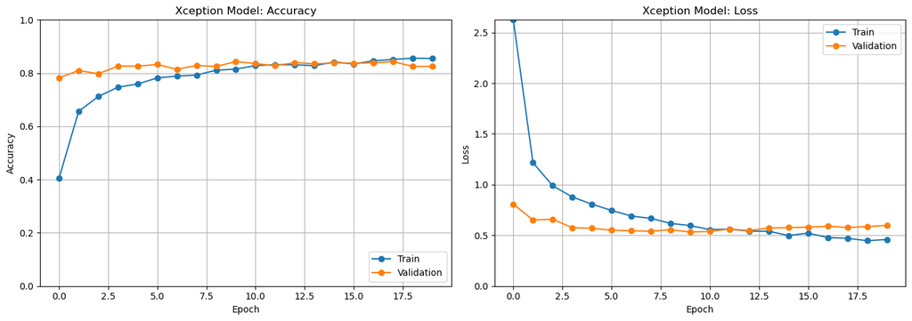

```python
plot_learning_behavior(train_results, "Xception Model")
```

### (IMPLEMENTATION) Load the Model with the Best Validation Loss

```python
### TODO: Load the model weights with the best validation loss.
Xception_model.load_weights('saved_models/weights.best.Xception.keras')
```

```python
# Modell mit samt Gewichten speichern
Xception_model.save("saved_models/Xception.keras")
```

```python
from tensorflow.keras.models import load_model

# Modell laden
Xception_model = load_model("saved_models/Xception.keras")
```

### (IMPLEMENTATION) Test the Model

Try out your model on the test dataset of dog images. Ensure that your test accuracy is greater than 60%.

```python
### TODO: Calculate classification accuracy on the test dataset.
# Test the model
test_predictions = Xception_model.predict(test_Xception, batch_size=20)
test_accuracy = 100 * np.mean(np.argmax(test_predictions, axis=1) == np.argmax(test_targets, axis=1))
print('Test accuracy: %.4f%%' % test_accuracy)
```

```
42/42 ━━━━━━━━━━━━━━━━━━━━ 0s 5ms/step
Test accuracy: 82.0574%
```

### (IMPLEMENTATION) Predict Dog Breed with the Model

Write a function that takes an image path as input and returns the dog breed (`Affenpinscher`, `Afghan_hound`, etc) that is predicted by your model.

Similar to the analogous function in Step 5, your function should have three steps:

1. Extract the bottleneck features corresponding to the chosen CNN model.
2. Supply the bottleneck features as input to the model to return the predicted vector. Note that the argmax of this prediction vector gives the index of the predicted dog breed.
3. Use the `dog_names` array defined in Step 0 of this notebook to return the corresponding breed.

The functions to extract the bottleneck features can be found in `extract_bottleneck_features.py`, and they have been imported in an earlier code cell. To obtain the bottleneck features corresponding to your chosen CNN architecture, you need to use the function

```
extract_{network}
```

where `{network}`, in the above filename, should be one of `VGG19`, `Resnet50`, `InceptionV3`, or `Xception`.

```python
def clean_breed_name(prediction):
    # Nutzt rsplit, um den Teil nach dem letzten Punkt zu extrahieren
    breed_name = prediction.rsplit(".", 1)[-1]
    return breed_name.replace("_", " ")
```

```python
### TODO: Write a function that takes a path to an image as input
### and returns the dog breed that is predicted by the model.

def predict_dog_breed(img_path):

    # Extract the bottleneck features
    bottleneck_features = extract_Xception(path_to_tensor(img_path))

    # Return the predicted vector
    predicted_vector = Xception_model.predict(bottleneck_features)

    # Return the corresponding breed.
    breed_index = np.argmax(predicted_vector)
    breed_name = dog_names[breed_index]
    breed_name_cleaned = clean_breed_name(breed_name)

    return breed_name_cleaned
```

## Step 6: Write your Algorithm

Write an algorithm that accepts a file path to an image and first determines whether the image contains a human, dog, or neither. Then,

- if a **dog** is detected in the image, return the predicted breed.
- if a **human** is detected in the image, return the resembling dog breed.
- if **neither** is detected in the image, provide output that indicates an error.

You are welcome to write your own functions for detecting humans and dogs in images, but feel free to use the `face_detector` and `dog_detector` functions developed above. You are **required** to use your CNN from Step 5 to predict dog breed.

A sample image and output for our algorithm is provided below, but feel free to design your own user experience!

[figure not shown]

This photo looks like an Afghan Hound.

### (IMPLEMENTATION) Write your Algorithm

```python
### TODO: Write your algorithm.
### Feel free to use as many code cells as needed.

def predict_image_category(img_path):

    # Schritt 1: Überprüfen, ob ein Hund im Bild ist
    if dog_detector(img_path):
        breed = predict_dog_breed(img_path)
        return f"Ein Hund wurde erkannt! Die vorhergesagte Hunderasse ist: {breed}"

    # Schritt 2: Überprüfen, ob ein Mensch im Bild ist
    elif face_detector(img_path):
        human_like_dog_breed = predict_dog_breed(img_path)
        return f"Ein Mensch wurde erkannt! Die ähnliche Hunderasse ist: {human_like_dog_breed}"

    # Schritt 3: Wenn weder ein Hund noch ein Mensch erkannt wurde
    else:
        return "Weder ein Hund noch ein Mensch wurde erkannt. Bitte geben Sie ein anderes Bild ein."
```

```python
# Test
img_path = 'D:/GIT/Assignement7/dog_images/train/125.Portuguese_water_dog/Portuguese_water_dog_07979.jpg'
output = predict_image_category(img_path)
print(output)
```

```
1/1 ━━━━━━━━━━━━━━━━━━━━ 1s 656ms/step
1/1 ━━━━━━━━━━━━━━━━━━━━ 3s 3s/step
1/1 ━━━━━━━━━━━━━━━━━━━━ 0s 68ms/step
Ein Hund wurde erkannt! Die vorhergesagte Hunderasse ist: Portuguese water dog
```

## Step 7: Test Your Algorithm

In this section, you will take your new algorithm for a spin! What kind of dog does the algorithm think that **you** look like? If you have a dog, does it predict your dog's breed accurately? If you have a cat, does it mistakenly think that your cat is a dog?

### (IMPLEMENTATION) Test Your Algorithm on Sample Images!

Test your algorithm at least six images on your computer. Feel free to use any images you like. Use at least two human and two dog images.

**Question 6:** Is the output better than you expected :) ? Or worse :( ? Provide at least three possible points of improvement for your algorithm.

**Answer:** The output is better then I expacted, but never the less categorizing very simillar dog breeds is hard. Either an enlarged training dataset for this breeds or an additional CNN layer which looks more for the small differences would help to futher improve the model.

```
1/1 ━━━━━━━━━━━━━━━━━━━━ 0s 404ms/step
1/1 ━━━━━━━━━━━━━━━━━━━━ 1s 1s/step
1/1 ━━━━━━━━━━━━━━━━━━━━ 0s 47ms/step
Ergebnis für D:/GIT/Assignement7/test_images/border-collie.jpg: Ein Hund wurde erkannt! Die vorhergesagte Hunderasse ist: Border collie
```

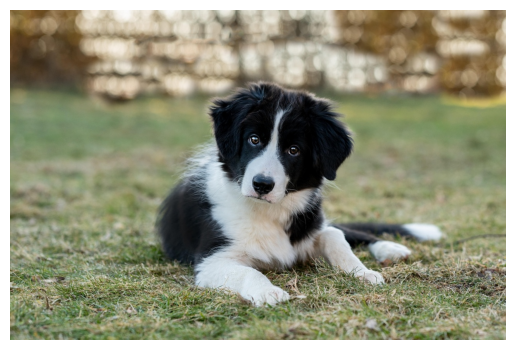

```
1/1 ━━━━━━━━━━━━━━━━━━━━ 0s 206ms/step
Ergebnis für D:/GIT/Assignement7/test_images/homer_simson.jpg: Weder ein Hund noch ein Mensch wurde erkannt. Bitte geben Sie ein anderes Bild ein.
```

[figure not shown]

```
1/1 ━━━━━━━━━━━━━━━━━━━━ 0s 201ms/step
1/1 ━━━━━━━━━━━━━━━━━━━━ 1s 976ms/step
1/1 ━━━━━━━━━━━━━━━━━━━━ 0s 24ms/step
Ergebnis für D:/GIT/Assignement7/test_images/cockapoo.jpg: Ein Hund wurde erkannt! Die vorhergesagte Hunderasse ist: Cocker spaniel
```

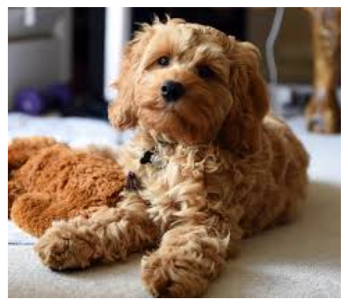

```
1/1 ━━━━━━━━━━━━━━━━━━━━ 0s 206ms/step
1/1 ━━━━━━━━━━━━━━━━━━━━ 1s 981ms/step
1/1 ━━━━━━━━━━━━━━━━━━━━ 0s 15ms/step
Ergebnis für D:/GIT/Assignement7/test_images/golden_retriever_1.jpg: Ein Hund wurde erkannt! Die vorhergesagte Hunderasse ist: Golden retriever
```

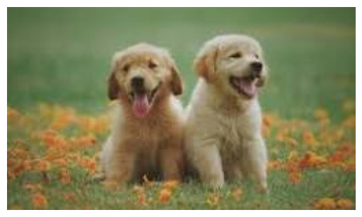

```
1/1 ━━━━━━━━━━━━━━━━━━━━ 0s 201ms/step
1/1 ━━━━━━━━━━━━━━━━━━━━ 1s 1s/step
1/1 ━━━━━━━━━━━━━━━━━━━━ 0s 32ms/step
Ergebnis für D:/GIT/Assignement7/test_images/golden_retriever_2.jpg: Ein Hund wurde erkannt! Die vorhergesagte Hunderasse ist: Golden retriever
```

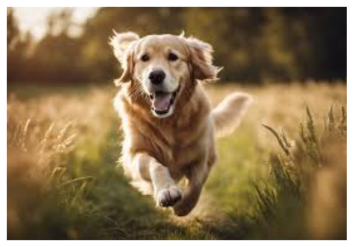

```
1/1 ━━━━━━━━━━━━━━━━━━━━ 0s 153ms/step
1/1 ━━━━━━━━━━━━━━━━━━━━ 1s 1s/step
1/1 ━━━━━━━━━━━━━━━━━━━━ 0s 31ms/step
Ergebnis für D:/GIT/Assignement7/test_images/labrador.jpg: Ein Hund wurde erkannt! Die vorhergesagte Hunderasse ist: Chesapeake bay retriever
```

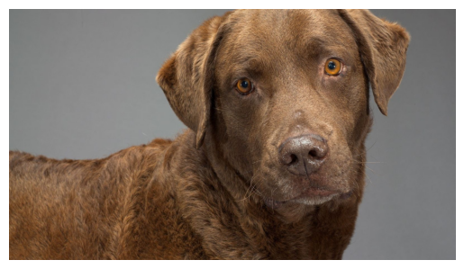

```
1/1 ━━━━━━━━━━━━━━━━━━━━ 0s 261ms/step
Ergebnis für D:/GIT/Assignement7/test_images/katze.jpg: Weder ein Hund noch ein Mensch wurde erkannt. Bitte geben Sie ein anderes Bild ein.
```

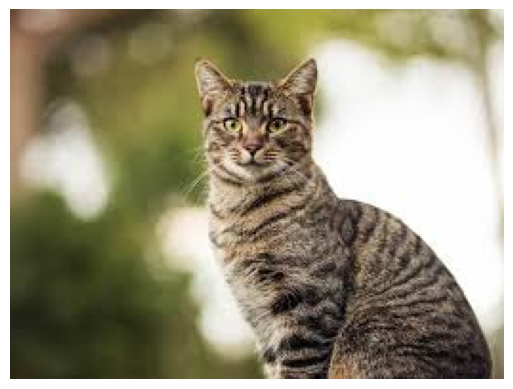

```
1/1 ━━━━━━━━━━━━━━━━━━━━ 0s 226ms/step
Ergebnis für D:/GIT/Assignement7/test_images/landscape.jpg: Weder ein Hund noch ein Mensch wurde erkannt. Bitte geben Sie ein anderes Bild ein.
```

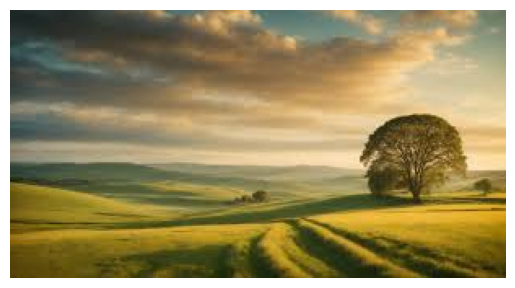

```python
## TODO: Execute your algorithm from Step 6 on
## at least 6 images on your computer.
## Feel free to use as many code cells as needed.

images = [
    'D:/GIT/Assignement7/test_images/border-collie.jpg',  # Bild von einem Hund
    'D:/GIT/Assignement7/test_images/homer_simson.jpg',  # Bild von einem Menschen
    'D:/GIT/Assignement7/test_images/cockapoo.jpg',    # Bild von einem Hund
    'D:/GIT/Assignement7/test_images/golden_retriever_1.jpg',    # Bild von einem Hund
    'D:/GIT/Assignement7/test_images/golden_retriever_2.jpg',     # Bild von einem Hund
    'D:/GIT/Assignement7/test_images/labrador.jpg',     # Bild von einem Hund
    'D:/GIT/Assignement7/test_images/katze.jpg', # Bild von einer Katze
    'D:/GIT/Assignement7/test_images/landscape.jpg', # Bild von einer Landschaft

]

for img_path in images:
    result = predict_image_category(img_path)
    print(f"Ergebnis für {img_path}: {result}")

    # Plot picture
    picture = cv2.imread(img_path)
    picture_rgb = cv2.cvtColor(picture, cv2.COLOR_BGR2RGB)
    plt.imshow(picture_rgb)
    plt.axis("off")
    plt.show()
```

```python
import pkg_resources

installed_packages = pkg_resources.working_set
for package in installed_packages:
    print(f"{package.key}=={package.version}")
```

[output not shown]

[output cut: 300 more lines]

[output not shown]